# PCSF CNV data

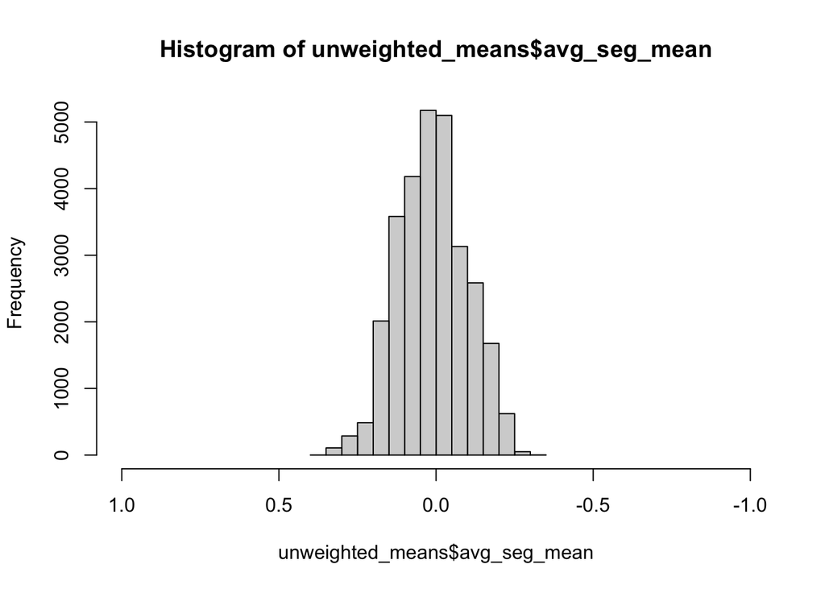

```r
hist(unweighted_means$avg_seg_mean, xlim = c(1, -1))
```

PCSF_run.R

```r
#devtools::install_github("IOR-Bioinformatics/PCSF", dependencies=TRUE, type="source", force=TRUE)


#dir.create("results")

#ensembl <- useMart("ensembl", dataset = "hsapiens_gene_ensembl")

# set seed for reproducability
set.seed(69)

# read in STRING data
weighted_string_data <- read.csv("data/weighted_string_data.csv", row.names = 1)
unweighted_string_data <- read.csv("data/unweighted_string_data.csv", row.names = 1)

# construct interactome
weighted_ppi <- construct_interactome(weighted_string_data)
unweighted_ppi <- construct_interactome(unweighted_string_data)

# read in seg mean data
weighted_data <- read.csv("data/weighted_pcsf_score.csv", row.names = 1)
unweighted_data <- read.csv("data/unweighted_pcsf_score.csv", row.names = 1)

# set terminals
weighted_terminals <- setNames(as.numeric(weighted_data$avg_seg_mean), weighted_data$ensembl_peptide_id)
unweighted_terminals <- setNames(as.numeric(unweighted_data$avg_seg_mean), unweighted_data$ensembl_peptide_id)

# run PCSF with random noise
weighted_subnet <- PCSF_rand(weighted_ppi, weighted_terminals, n = 50, r = 0.1, w = 2, b = 3, mu = 0.0005)
```

```
##   10.13% of your terminal nodes are included in the interactome
##   Solving the PCSF by adding random noise to the edge costs...
```

```r
#plot.PCSF(weighted_subnet, node_label_cex = 15)

unweighted_subnet <- PCSF_rand(unweighted_ppi, unweighted_terminals, n = 10, r = 0.1, w = 2, b = 3, mu = 0.0005)
```

```
##   10.78% of your terminal nodes are included in the interactome
##   Solving the PCSF by adding random noise to the edge costs...
```

```r
#plot.PCSF(unweighted_subnet, node_label_cex = 15)

# extract cluster data
weighted_clust <- clusters(weighted_subnet)
weighted_df <- data.frame(ensembl_peptide_id = names(weighted_clust$membership), cluster = factor(weighted_clust$membership))

# Calculate betweenness and centrality scores
weighted_betweenness <- betweenness(weighted_subnet) # number of shortest paths through node. number of times node acts as a bridge to other nodes
weighted_centrality <- degree(weighted_subnet) # how many connections each protein has

# Add betweenness and centrality scores to the cluster data frame
weighted_df$betweenness <- weighted_betweenness[as.character(weighted_df$ensembl_peptide_id)]
weighted_df$degree_centrality <- weighted_centrality[as.character(weighted_df$ensembl_peptide_id)]

# convert betweeness and centrality scores to integers
weighted_df$betweenness <- as.integer(weighted_df$betweenness)
weighted_df$degree_centrality <- as.integer(weighted_df$degree_centrality)

# format row names
rownames(weighted_df) <- 1:nrow(weighted_df)

# add a uniprot id column
weighted_uniprots <- getBM(attributes = c("ensembl_peptide_id", "uniprotswissprot"),
                              filters = "ensembl_peptide_id",
                              values = weighted_df$ensembl_peptide_id,
                              mart = ensembl)

weighted_df <- merge(weighted_df, weighted_uniprots, by.x = "ensembl_peptide_id")

# format columns
weighted_df <- weighted_df[, c("ensembl_peptide_id", "uniprotswissprot", "cluster", "betweenness","degree_centrality")]
colnames(weighted_df)[2] <- "uniprot_id"

# sort by cluster number
weighted_df <- weighted_df[order(weighted_df$cluster), ]

# save to results dir
#write.csv(weighted_df, "results/weighted_pcsf_results.csv", row.names = F)

# repeat for unweighted data
unweighted_clust <- clusters(unweighted_subnet)
unweighted_df <- data.frame(ensembl_peptide_id = names(unweighted_clust$membership), cluster = factor(unweighted_clust$membership))
unweighted_betweenness <- betweenness(unweighted_subnet)
unweighted_centrality <- degree(unweighted_subnet)
unweighted_df$betweenness <- unweighted_betweenness[as.character(unweighted_df$ensembl_peptide_id)]
unweighted_df$degree_centrality <- unweighted_centrality[as.character(unweighted_df$ensembl_peptide_id)]
unweighted_df$betweenness <- as.integer(unweighted_df$betweenness)
unweighted_df$degree_centrality <- as.integer(unweighted_df$degree_centrality)

rownames(unweighted_df) <- 1:nrow(unweighted_df)
unweighted_uniprots <- getBM(attributes = c("ensembl_peptide_id", "uniprotswissprot"),
                           filters = "ensembl_peptide_id",
                           values = unweighted_df$ensembl_peptide_id,
                           mart = ensembl)
unweighted_df <- merge(unweighted_df, unweighted_uniprots, by.x = "ensembl_peptide_id")
unweighted_df <- unweighted_df[, c("ensembl_peptide_id", "uniprotswissprot", "cluster", "betweenness","degree_centrality")]
colnames(unweighted_df)[2] <- "uniprot_id"
unweighted_df <- unweighted_df[order(unweighted_df$cluster), ]

#write.csv(unweighted_df, "results/unweighted_pcsf_results.csv", row.names = F)
```

druggability_cross_ref.R

```r
# read in data
af_drugability <- read.csv("data/druggability/fpocket_druggability.csv")
weighted_pcsf <- read.csv("results/weighted_pcsf_results.csv")
unweighted_pcsf <- read.csv("results/unweighted_pcsf_results.csv")

# merge AF data with PCSF data by uniprot ID
weighted_pcsf_master <- merge(weighted_pcsf, af_drugability, by.x = "uniprot_id")
weighted_pcsf_master <- subset(weighted_pcsf_master, select = c("ensembl_peptide_id", "uniprot_id", "cluster", "betweenness",
                                                                "degree_centrality", "pocket", "druggability", "num_drug_pockets"))
weighted_pcsf_master <- weighted_pcsf_master[order(-weighted_pcsf_master$druggability), ]

#write.csv(weighted_pcsf_master, "results/weighted_PCSF_druggability.csv")

# repeat for unweighted
unweighted_pcsf_master <- merge(unweighted_pcsf, af_drugability, by.x = "uniprot_id")
unweighted_pcsf_master <- subset(unweighted_pcsf_master, select = c("ensembl_peptide_id", "uniprot_id", "cluster", "betweenness",
                                                                "degree_centrality", "pocket", "druggability", "num_drug_pockets"))
unweighted_pcsf_master <- unweighted_pcsf_master[order(-unweighted_pcsf_master$druggability), ]

#write.csv(unweighted_pcsf_master, "results/unweighted_PCSF_druggability.csv")
```

## Weighted vs un-weighted

### Weighted CNV data

```r
data <- read.csv("results/weighted_PCSF_druggability.csv", row.names = 1)
kable(data, row.names = F)
```

| ensembl_peptide_id | uniprot_id | cluster | betweenness | degree_centrality | pocket | druggability | num_drug_pockets |
| --- | --- | --- | --- | --- | --- | --- | --- |
| ENSP00000404854 | Q92597 | 1 | 6 | 2 | 0.317 | 0.960 | 1 |
| ENSP00000241261 | P50591 | 1 | 0 | 1 | 0.184 | 0.940 | 1 |
| ENSP00000348161 | Q9UJ42 | 2 | 0 | 2 | 0.089 | 0.879 | 1 |
| ENSP00000333037 | Q9BYD9 | 3 | 0 | 1 | 0.090 | 0.821 | 1 |
| ENSP00000250160 | O95388 | 1 | 0 | 1 | 0.174 | 0.570 | 2 |
| ENSP00000414635 | Q8IZ02 | 3 | 0 | 1 | 0.488 | 0.555 | 1 |
| ENSP00000391299 | Q7Z3H4 | 2 | 0 | 1 | 0.286 | 0.434 | 1 |
| ENSP00000295797 | P41743 | 2 | 4 | 2 | 0.145 | 0.340 | 0 |
| ENSP00000326240 | Q9NPC7 | 3 | 0 | 1 | 0.180 | 0.318 | 0 |
| ENSP00000337688 | Q99442 | 2 | 0 | 2 | 0.094 | 0.307 | 0 |
| ENSP00000276708 | Q9BYG8 | 1 | 0 | 1 | 0.060 | 0.210 | 0 |
| ENSP00000312150 | Q96RU8 | 1 | 0 | 1 | 0.268 | 0.201 | 0 |
| ENSP00000325978 | Q6UY01 | 3 | 6 | 4 | 0.168 | 0.181 | 0 |
| ENSP00000319305 | Q7Z3I7 | 1 | 6 | 2 | 0.086 | 0.068 | 0 |
| ENSP00000415243 | P12757 | 2 | 8 | 4 | 0.058 | 0.059 | 0 |
| ENSP00000342188 | A6NIV6 | 3 | 0 | 1 | 0.118 | 0.046 | 0 |
| ENSP00000302578 | Q96KN1 | 1 | 14 | 3 | 0.058 | 0.005 | 0 |

```r
plot.PCSF(weighted_subnet, node_label_cex = 15)
```

[interactive chart not shown]

### unWeighted CNV data

```r
data <- read.csv("results/unweighted_PCSF_druggability.csv", row.names = 1)
kable(data, row.names = F)
```

| ensembl_peptide_id | uniprot_id | cluster | betweenness | degree_centrality | pocket | druggability | num_drug_pockets |
| --- | --- | --- | --- | --- | --- | --- | --- |
| ENSP00000286355 | P40145 | 2 | 4 | 2 | 0.131 | 0.968 | 1 |
| ENSP00000404854 | Q92597 | 1 | 12 | 2 | 0.317 | 0.960 | 1 |
| ENSP00000265896 | Q14534 | 1 | 0 | 1 | 0.304 | 0.953 | 2 |
| ENSP00000241261 | P50591 | 1 | 0 | 1 | 0.184 | 0.940 | 1 |
| ENSP00000231706 | Q8TBB6 | 1 | 12 | 2 | 0.296 | 0.916 | 2 |
| ENSP00000318016 | Q12768 | 1 | 12 | 3 | 0.233 | 0.907 | 1 |
| ENSP00000348161 | Q9UJ42 | 3 | 2 | 2 | 0.089 | 0.879 | 1 |
| ENSP00000333037 | Q9BYD9 | 4 | 0 | 1 | 0.090 | 0.821 | 1 |
| ENSP00000419298 | Q06416 | 1 | 0 | 1 | 0.357 | 0.776 | 1 |
| ENSP00000264674 | Q03112 | 3 | 0 | 1 | 0.111 | 0.584 | 1 |
| ENSP00000250160 | O95388 | 1 | 0 | 1 | 0.174 | 0.570 | 2 |
| ENSP00000414635 | Q8IZ02 | 4 | 0 | 1 | 0.488 | 0.555 | 1 |
| ENSP00000254627 | Q02509 | 2 | 0 | 1 | 0.471 | 0.524 | 1 |
| ENSP00000484634 | Q86X45 | 2 | 0 | 1 | 0.105 | 0.463 | 1 |
| ENSP00000391299 | Q7Z3H4 | 3 | 0 | 1 | 0.286 | 0.434 | 1 |
| ENSP00000295797 | P41743 | 3 | 8 | 2 | 0.145 | 0.340 | 0 |
| ENSP00000326240 | Q9NPC7 | 4 | 0 | 1 | 0.180 | 0.318 | 0 |
| ENSP00000346080 | Q6P5R6 | 1 | 0 | 1 | 0.308 | 0.315 | 0 |
| ENSP00000337688 | Q99442 | 3 | 0 | 2 | 0.094 | 0.307 | 0 |
| ENSP00000373648 | O43525 | 2 | 0 | 1 | 0.045 | 0.284 | 0 |
| ENSP00000276708 | Q9BYG8 | 1 | 0 | 1 | 0.060 | 0.210 | 0 |
| ENSP00000312150 | Q96RU8 | 1 | 30 | 2 | 0.268 | 0.201 | 0 |
| ENSP00000325978 | Q6UY01 | 4 | 6 | 4 | 0.168 | 0.181 | 0 |
| ENSP00000319305 | Q7Z3I7 | 1 | 50 | 4 | 0.086 | 0.068 | 0 |
| ENSP00000415243 | P12757 | 3 | 11 | 4 | 0.058 | 0.059 | 0 |
| ENSP00000342188 | A6NIV6 | 4 | 0 | 1 | 0.118 | 0.046 | 0 |
| ENSP00000254624 | Q14156 | 2 | 7 | 3 | 0.112 | 0.039 | 0 |
| ENSP00000295822 | Q9GZV4 | 1 | 22 | 2 | 0.206 | 0.026 | 0 |
| ENSP00000302578 | Q96KN1 | 1 | 44 | 4 | 0.058 | 0.005 | 0 |

```r
plot.PCSF(unweighted_subnet, node_label_cex = 15)
```

[interactive chart not shown]

#### Here’s how the data changed through this pipeline:

- Original data = 40,066 genes
- Removed genes with seg mean between -0.3 and 0.3
  - Weighted = 87 genes
  - unWieghted = 110 genes
- Converted genes to protein Ensembles for cytoscape:
  - Weighted = 227 proteins
  - unWeighted = 334 proteins
- Cytoscape/STRING output:
  - Weighted = 37
  - unWeighted = 53
- PCSF network:
  - Weighted = 19
  - unWeighted = 32
- Converted protein Ensembl to Uniprot IDs
  - Weighted = 18
  - unWeighted = 30
- Cross referenced Uniprot IDs with AlphaFold structrues (druggability):
  - Weighted = 17
  - unWeighted = 29